# Stat 108: Lab 4

Dylan Scoble

2/9/2022

### Exercise 1

There are 1,258 observations in the new dataset, after we filter for observations that have a carat weight of 0.5.

```r
data <- diamonds %>%
  filter(carat == 0.5)
glimpse(data)
```

```
## Rows: 1,258
## Columns: 10
## $ carat   <dbl> 0.5, 0.5, 0.5, 0.5, 0.5, 0.5, 0.5, 0.5, 0.5, 0.5, 0.5, 0.5, 0.…
## $ cut     <ord> Ideal, Ideal, Good, Good, Very Good, Fair, Fair, Fair, Fair, F…
## $ color   <ord> E, E, D, D, D, F, F, F, F, F, G, F, E, G, G, F, F, E, E, F, E,…
## $ clarity <ord> VVS2, VVS2, VVS2, IF, IF, I1, I1, I1, I1, I1, I1, I1, I1, I1, …
## $ depth   <dbl> 62.2, 62.2, 62.4, 63.2, 62.9, 69.8, 71.0, 68.4, 67.1, 68.3, 64…
## $ table   <dbl> 54, 54, 64, 59, 59, 55, 57, 54, 57, 58, 60, 58, 61, 57, 56, 60…
## $ price   <int> 2889, 2889, 3017, 3378, 3378, 584, 613, 613, 627, 627, 701, 71…
## $ x       <dbl> 5.08, 5.09, 5.03, 4.99, 4.99, 4.89, 4.87, 4.94, 4.92, 4.91, 5.…
## $ y       <dbl> 5.12, 5.11, 5.06, 5.04, 5.09, 4.80, 4.79, 4.82, 4.87, 4.78, 4.…
## $ z       <dbl> 3.17, 3.17, 3.14, 3.17, 3.17, 3.38, 3.43, 3.35, 3.28, 3.32, 3.…
```

### Exercise 2

As shown in the histogram, the two levels of cut with the smallest number of observations are “few” and “good”.

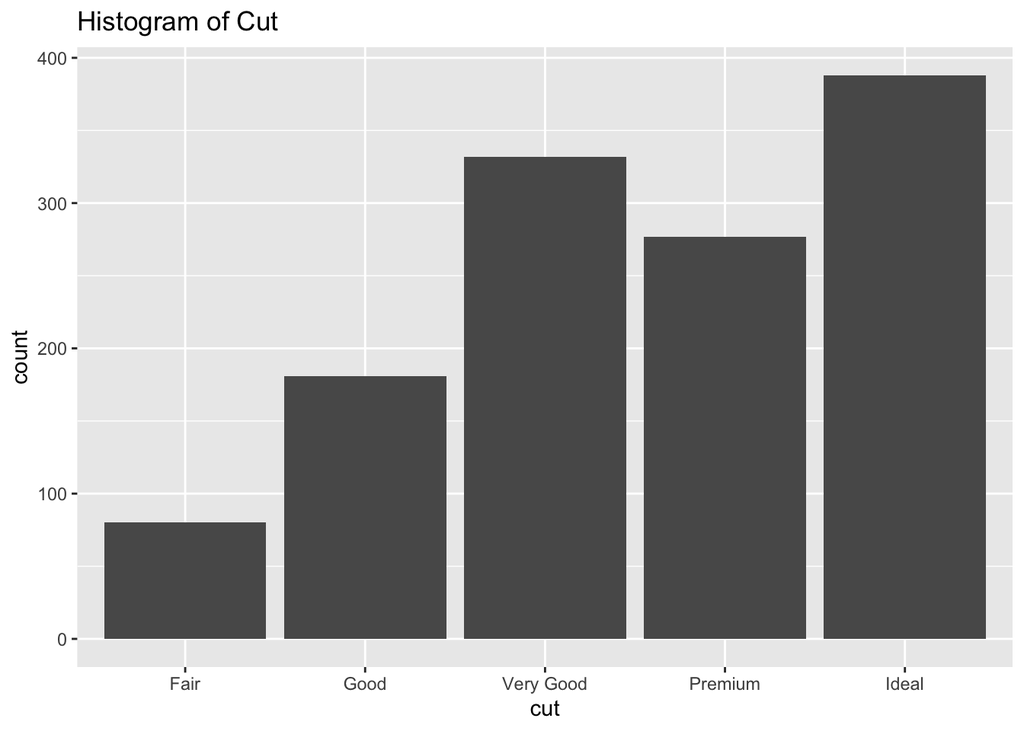

```r
ggplot(data = data, aes(x = cut)) +
  geom_bar() +
  labs(title = "Histogram of Cut")
```

### Exercise 3

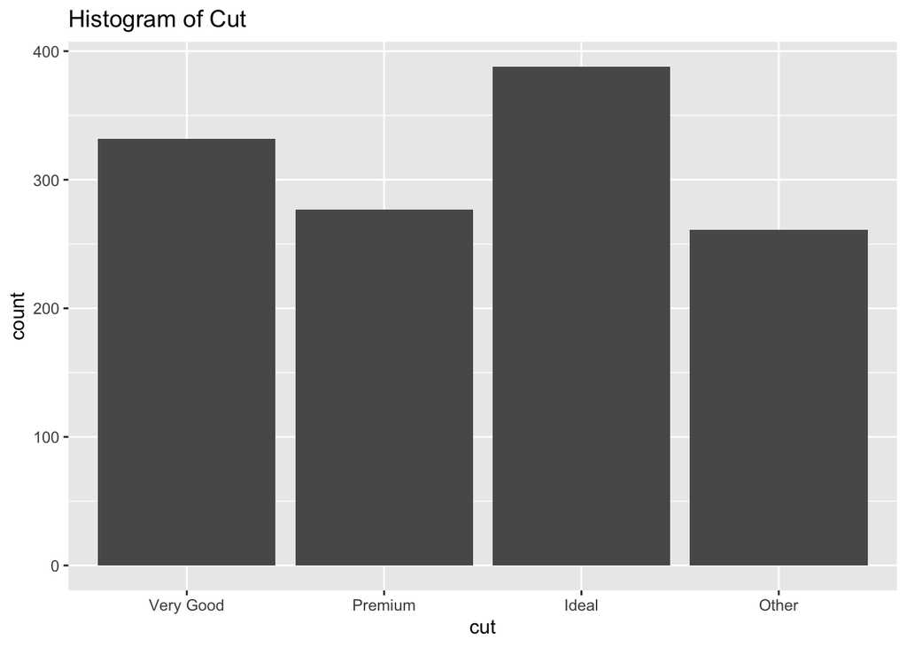

```r
lumpeddata <- data %>%
  mutate(cut = fct_lump_n(cut, n=3))

ggplot(data = lumpeddata, aes(x = cut)) +
  geom_bar() +
  labs(title = "Histogram of Cut")
```

### Exercise 4

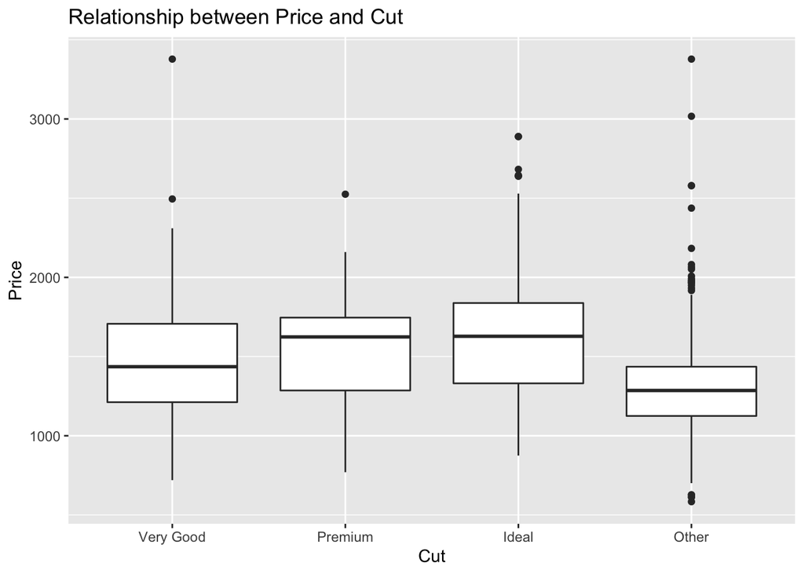

```r
plot <- ggplot(data = lumpeddata, aes(x = cut, y = price)) +
  geom_boxplot() +
  labs(title = "Relationship between Price and Cut",
       x = "Cut",
       y = "Price")

plot
```

### Exercise 5

The output of this code is a table that shows the mean, standard deviation, and number of observations of price for each category of cut.

```r
lumpeddata %>%
  group_by(cut) %>%
  summarise(mean = mean(price),
            std_dev = sd(price),
            num_observations = n()
  )
```

```
## # A tibble: 4 × 4
##   cut        mean std_dev num_observations
##   <ord>     <dbl>   <dbl>            <int>
## 1 Very Good 1489.    339.              332
## 2 Premium   1532.    304.              277
## 3 Ideal     1609.    368.              388
## 4 Other     1341.    365.              261
```

### Exercise 6

For Diamonds that are 0.5 carats, there is a minor linear relationship between cut and price. As cut increases from less than very good, to very good, to premium, to ideal, the mean price of that category also increases.

### Exercise 7

The following code will test the normality assumption. The output of this code allows me to conclude that the normality assumption is satisfied because each plot folllows a relatively normal distribution.

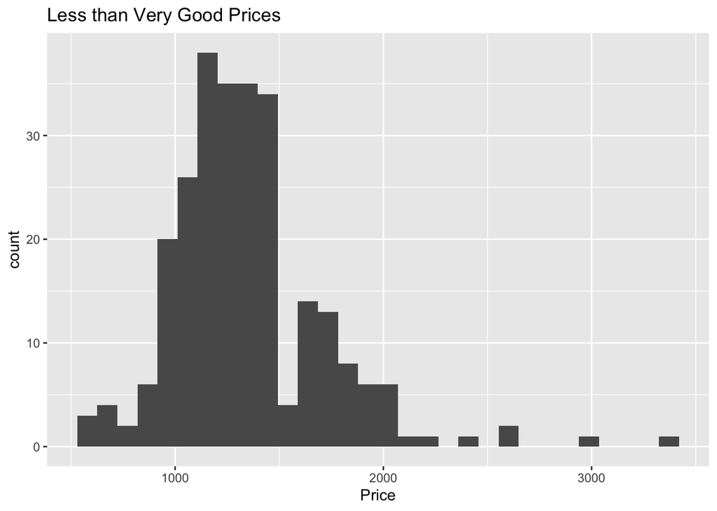

```r
badcut <- lumpeddata %>%
  filter(cut == "Other")
ggplot(data = badcut, aes(x = price)) +
  geom_histogram() +
  labs(title = "Less than Very Good Prices",
       x = "Price")
```

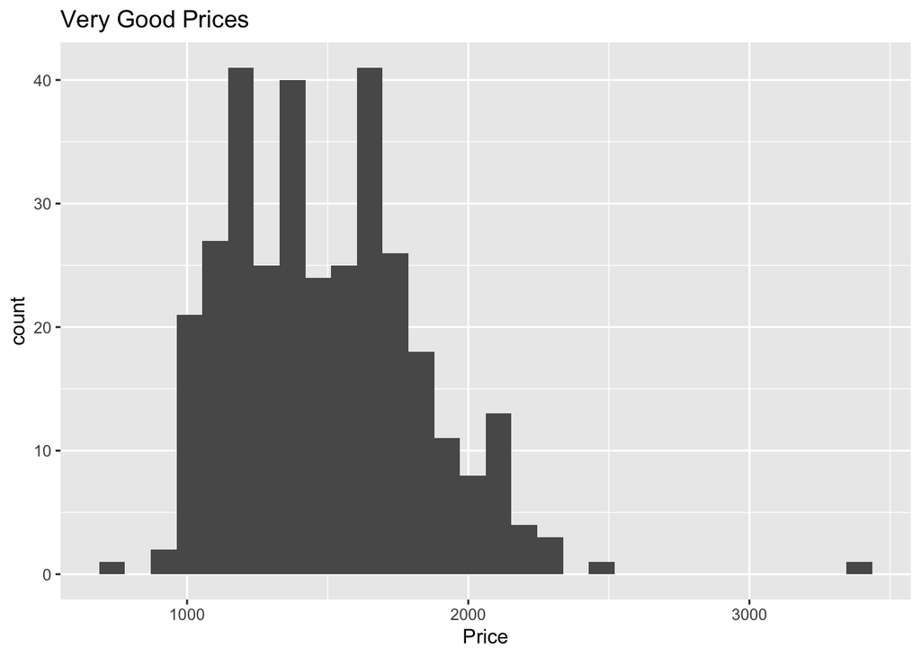

```r
verygoodcut <- lumpeddata %>%
  filter(cut == "Very Good")
ggplot(data = verygoodcut, aes(x = price)) +
  geom_histogram() +
  labs(title = "Very Good Prices",
       x = "Price")
```

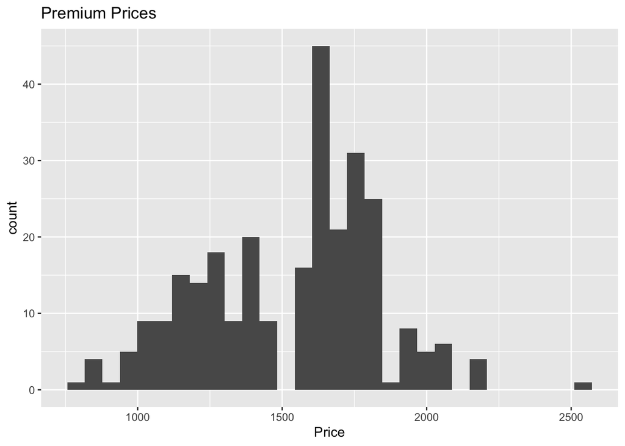

```r
premiumcut <- lumpeddata %>%
  filter(cut == "Premium")
ggplot(data = premiumcut, aes(x = price)) +
  geom_histogram() +
  labs(title = "Premium Prices",
       x = "Price")
```

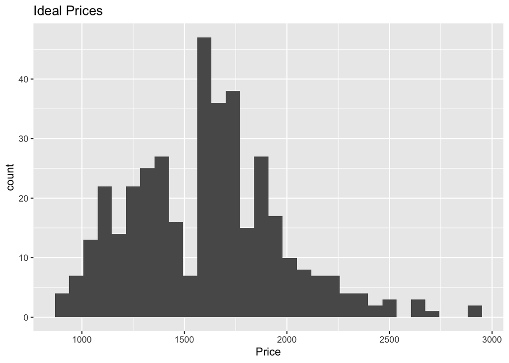

```r
idealcut <- lumpeddata %>%
  filter(cut == "Ideal")
ggplot(data = idealcut, aes(x = price)) +
  geom_histogram() +
  labs(title = "Ideal Prices",
       x = "Price")
```

The following code will test the constant variance assumption.

```r
model <- lm(price ~ cut, data = lumpeddata)
tidy(model) %>%
  kable(format="markdown", digits=3)
```

| term | estimate | std.error | statistic | p.value |
| --- | --- | --- | --- | --- |
| (Intercept) | 1492.438 | 9.893 | 150.852 | 0 |
| cut.L | -82.101 | 20.181 | -4.068 | 0 |
| cut.Q | -155.569 | 19.787 | -7.862 | 0 |
| cut.C | -84.678 | 19.384 | -4.368 | 0 |

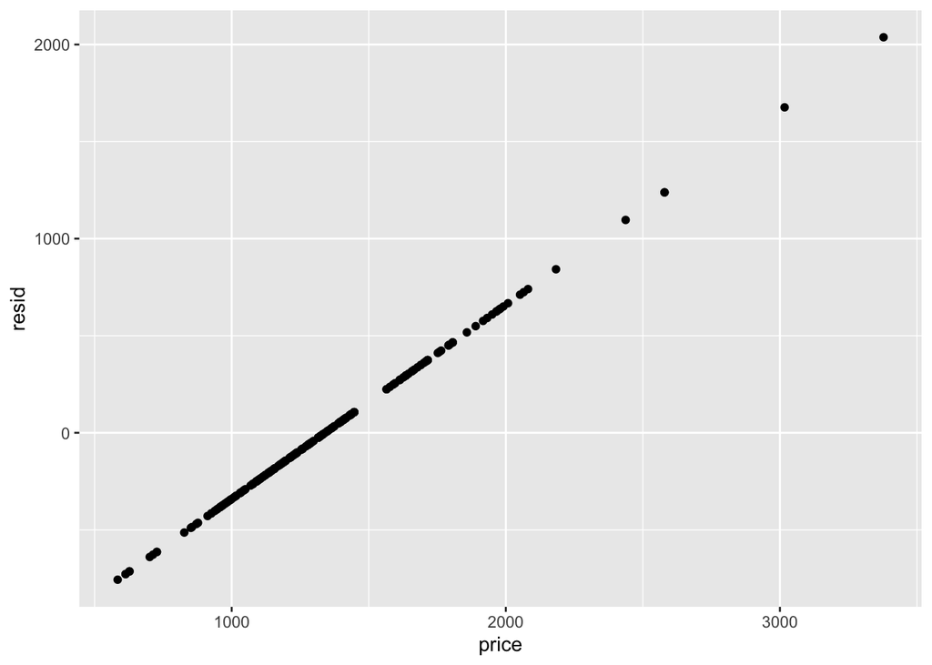

```r
lumpeddata <- lumpeddata %>%
  mutate(resid = residuals(model))

badcut <- lumpeddata %>%
  filter(cut == "Other")
ggplot(data = badcut, aes(x = price, y = resid)) +
  geom_point()
```

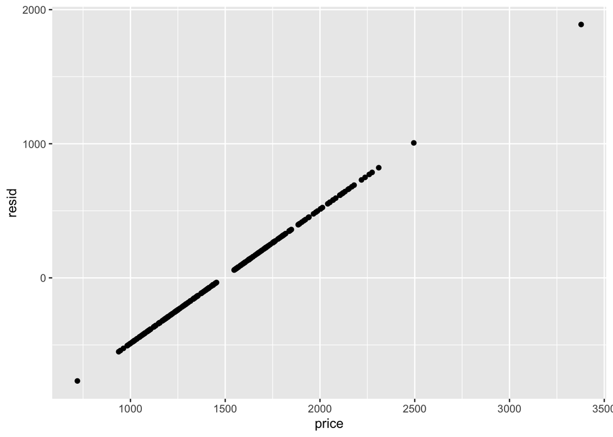

```r
verygoodcut <- lumpeddata %>%
  filter(cut == "Very Good")
ggplot(data = verygoodcut, aes(x = price, y = resid)) +
  geom_point()
```

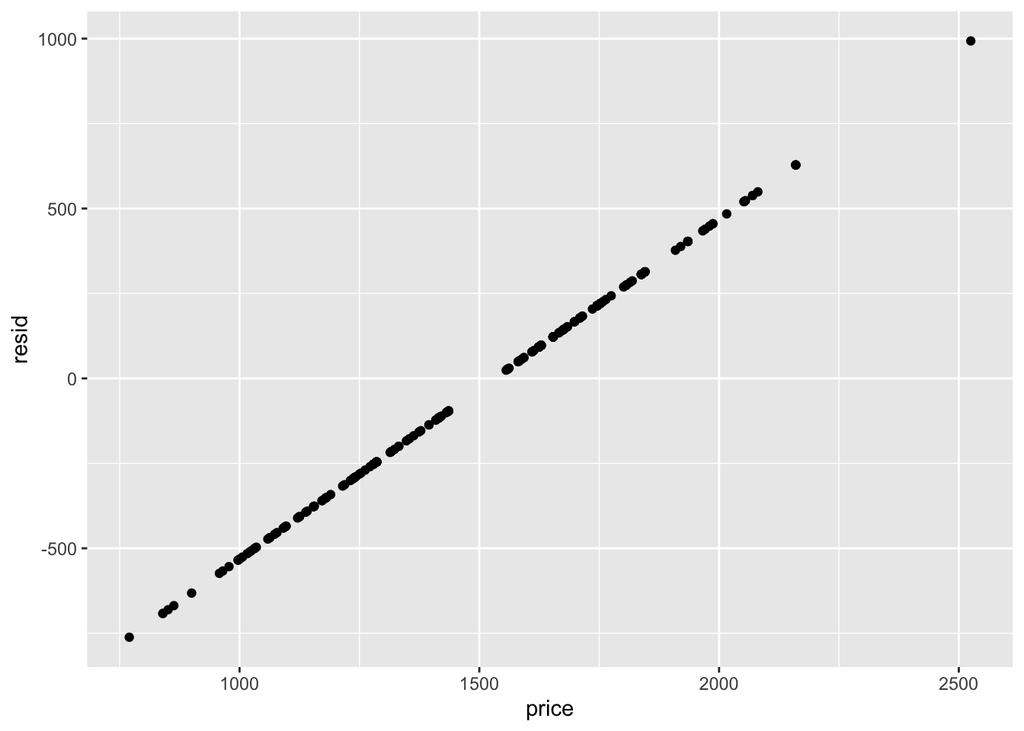

```r
premiumcut <- lumpeddata %>%
  filter(cut == "Premium")
ggplot(data = premiumcut, aes(x = price, y = resid)) +
  geom_point()
```

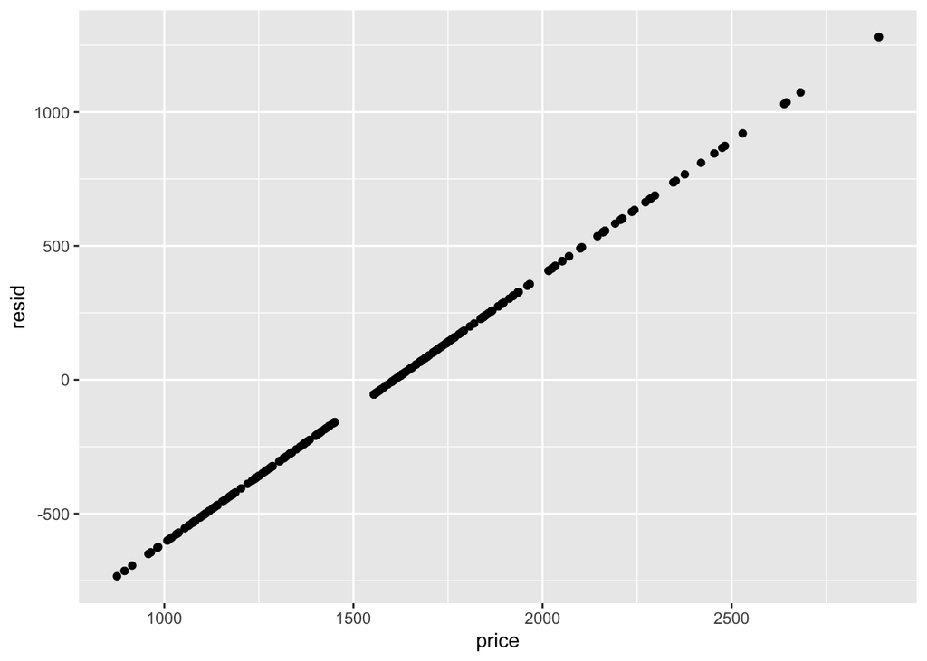

```r
idealcut <- lumpeddata %>%
  filter(cut == "Ideal")
ggplot(data = idealcut, aes(x = price, y = resid)) +
  geom_point()
```

The constant variance assumption is not satisfied because for each level of price, there is not a cloud-shaped pattern to represent the relationship between cut and price.

### Exercise 8

```r
model <- lm(price ~ cut, data = lumpeddata)
kable(anova(model), format="markdown",digits=6)
```

|  | Df | Sum Sq | Mean Sq | F value | Pr(>F) |
| --- | --- | --- | --- | --- | --- |
| cut | 3 | 11507056 | 3835685.3 | 31.916 | 0 |
| Residuals | 1254 | 150706506 | 120180.6 | NA | NA |

### Exercise 10

```r
tidy(model) %>%
  kable(format="markdown", digits=3)
```

| term | estimate | std.error | statistic | p.value |
| --- | --- | --- | --- | --- |
| (Intercept) | 1492.438 | 9.893 | 150.852 | 0 |
| cut.L | -82.101 | 20.181 | -4.068 | 0 |
| cut.Q | -155.569 | 19.787 | -7.862 | 0 |
| cut.C | -84.678 | 19.384 | -4.368 | 0 |

```r
summary(model)$coef[,2]
```

```
## (Intercept)       cut.L       cut.Q       cut.C
##    9.893372   20.181275   19.786744   19.384185
```

### Exercise 11

The null hypothesis states that there is not a statistically significant difference in price between each level of cut. The alternative hypothesis states that there is a statistically significant difference in price between each level of cut. In a mathematical sense, $H_0: mean(price: cut = very good) = mean(price: cut = premium) = mean(price: cut = ideal) = mean(price: cut = other)$

$H_A: !(mean(price: cut = very good) = mean(price: cut = premium) = mean(price: cut = ideal) = mean(price: cut = other))$

### Exercise 12

Because the F statistic is very high in our ANOVA analysis, the p-value is low. Therefore, we can reject the null hypothesis that cut does not affect price and accept the alternative hypothesis.